# Introduction to diezeit

2015-10-19

# Introduction to `diezeit`

### About the package

`diezeit` is an R wrapper for the ZEIT ONLINE Content API, available at http://developer.zeit.de. It gives access to articles and corresponding metadata from the ZEIT archive dating back to 1946 and from ZEIT ONLINE. The API can be used for free for non-commercial use cases. For the terms of use see http://developer.zeit.de/licence (German only at the moment).

A personal API key is required for usage and can be requested at http://developer.zeit.de/quickstart. Registration is free and allows for API-Access with a limit of 10,000 requests per day. If you do not want to enter your key for each R session, put the following in your .Renviron or .Rprofile file: `ZEIT_KEY=PUTYOURKEYHERE`.

### Package install

`diezeit` is available on CRAN and GitHub. Install from CRAN:

`install.packages(“diezeit”)

To install the development version from GitHub the `devtools`-package is required.

```r
if(packageVersion("devtools") < 1.6) {
  install.packages("devtools")
}
devtools::install_github("chgrl/diezeit")
```

### Load the package

```r
library(diezeit)
```

### Search the ZEIT archive

#### Content search

The `content`-endpoint exposes an unfiltered search for articles. You can set search queries, paginate, sort and partially select the fields, that should be returned. Articles, that match your query, are returned with a reduced set of meta data.

```r
zeit_search(endpoint="content", query="bayreuth")
```

```
#> $matches
#> $matches[[1]]
#> $matches[[1]]$subtitle
#> [1] "Wird auf der Opernbühne wieder mehr verboten, interveniert und zensiert? Die Angst vor einem Skandal ist ein feiner Indikator für unsere gesellschaftliche Realität"
#>
#> $matches[[1]]$uuid
#> [1] "6koVP1iuVDyvRkzWmSz2nG"
#>
#> $matches[[1]]$title
#> [1] "Köpfe ab!"
#>
#> $matches[[1]]$href
#> [1] "http://www.zeit.de/2015/39/oper-skandal-urheberrecht-zensur"
#>
#> $matches[[1]]$release_date
#> [1] "2015-10-08T02:00:19Z"
#>
#> $matches[[1]]$uri
#> [1] "http://api.zeit.de/content/6koVP1iuVDyvRkzWmSz2nG"
#>
#> $matches[[1]]$snippet
#> [1] " geradezu ergebnisoffen, oft haben sie Geschichte gemacht wie die Ring-Inszenierung von Patrice Chéreau, 1976 in <em>Bayreuth</em> mit Wutgeheul und Morddrohungen begrüßt – und ein Jahr später schon Kult.\nEtlichen"
#>
#> $matches[[1]]$supertitle
#> [1] "Opernregie"
#>
#> $matches[[1]]$teaser_text
#> [1] "Wird auf der Opernbühne wieder mehr verboten, interveniert und zensiert? Die Angst vor einem Skandal ist ein feiner Indikator für unsere gesellschaftliche Realität."
#>
#> $matches[[1]]$teaser_title
#> [1] "Köpfe ab? Köpfe ab!"
#>
#>
#> $matches[[2]]
#> $matches[[2]]$subtitle
#> [1] "Der heißlaufende Streit um Namenspatrone (nicht nur) in Deutschland – und was dahintersteckt. Beobachtungen"
#>
#> $matches[[2]]$uuid
#> [1] "5RQOFFRriS05dw4DfL2YEa"
#>
```

[output cut: 275 more lines]

```
#> [1] "Ein Militärflugzeug vom Typ F-16 ist über einem Waldgebiet in Oberfranken abgestürzt. Vermutlich hatte es Munition an Bord. Der Pilot rettete sich mit dem Fallschirm."
#>
#> $matches[[10]]$teaser_title
#> [1] "Kampfjet in Bayern abgestürzt"
#>
#>
#>
#> $found
#> [1] 1567
#>
#> $limit
#> [1] 10
#>
#> $offset
#> [1] 0
```

The search uses entire strings “as is”.

```r
zeit_search("content", "bayreuther festspiele")
```

```
#> $matches
#> $matches[[1]]
#> $matches[[1]]$subtitle
#> [1] "Als Adolf Hitler Bayreuth besuchte, filmte das der junge Wolfgang Wagner. Der Streifen gilt als verschollen – doch 1975 hielt der Regisseur Hans-Jürgen Syberberg Bilder daraus fest. Hier zeigen wir sie erstmals."
#>
#> $matches[[1]]$uuid
#> [1] "1sRgadMwUk0eO8AniNz9I"
#>
#> $matches[[1]]$title
#> [1] "Tee mit dem Biedermann"
#>
#> $matches[[1]]$href
#> [1] "http://www.zeit.de/2015/31/bayreuth-festspiele-hitler-winifred-film"
#>
#> $matches[[1]]$release_date
#> [1] "2015-08-13T00:24:03Z"
#>
#> $matches[[1]]$uri
#> [1] "http://api.zeit.de/content/1sRgadMwUk0eO8AniNz9I"
#>
#> $matches[[1]]$snippet
#> [1] ", Requiem für einen jungfräulichen König (1972) oder Hitler, ein Film aus Deutschland (1977) früh an deutschen Mythen abgearbeitet hat. 1975, ein Jahr vor dem 100. Geburtstag der <em>Bayreuther</em> <em>Festspiele</em>, drehte"
#>
#> $matches[[1]]$supertitle
#> [1] "Bayreuth"
#>
#> $matches[[1]]$teaser_text
#> [1] "Als Adolf Hitler Bayreuth besuchte, filmte das der junge Wolfgang Wagner. Der Streifen gilt als verschollen – doch es gibt Fotos, die wir hier erstmals zeigen."
#>
#> $matches[[1]]$teaser_title
#> [1] "Zum Tee mit Hitler"
#>
#>
#> $matches[[2]]
#> $matches[[2]]$subtitle
#> [1] "Christian Thielemann darf sich mit einem neuen Titel schmücken. Dafür ist ihm seine Isolde abgesprungen. Und was hat das mit den Berliner Philharmonikern zu tun?"
#>
#> $matches[[2]]$uuid
#> [1] "1EsZprDHI0bIweeyEDcpG6"
#>
```

[output cut: 275 more lines]

```
#> [1] "Eva Wagner-Pasquier wird ihren Vertrag als Leiterin der Bayreuther Festspiele nicht verlängern. Sie teilt den Posten mit ihrer Schwester Katharina Wagner seit 2008."
#>
#> $matches[[10]]$teaser_title
#> [1] "Wagner-Pasquier verlässt Festspielleitung"
#>
#>
#>
#> $found
#> [1] 181
#>
#> $limit
#> [1] 10
#>
#> $offset
#> [1] 0
```

To search for multiple tokens use a vector of strings.

```r
zeit_search("content", c("bayreuth", "festspiele"))
```

```
#> $matches
#> $matches[[1]]
#> $matches[[1]]$subtitle
#> [1] "Wird auf der Opernbühne wieder mehr verboten, interveniert und zensiert? Die Angst vor einem Skandal ist ein feiner Indikator für unsere gesellschaftliche Realität"
#>
#> $matches[[1]]$uuid
#> [1] "6koVP1iuVDyvRkzWmSz2nG"
#>
#> $matches[[1]]$title
#> [1] "Köpfe ab!"
#>
#> $matches[[1]]$href
#> [1] "http://www.zeit.de/2015/39/oper-skandal-urheberrecht-zensur"
#>
#> $matches[[1]]$release_date
#> [1] "2015-10-08T02:00:19Z"
#>
#> $matches[[1]]$uri
#> [1] "http://api.zeit.de/content/6koVP1iuVDyvRkzWmSz2nG"
#>
#> $matches[[1]]$snippet
#> [1] " geradezu ergebnisoffen, oft haben sie Geschichte gemacht wie die Ring-Inszenierung von Patrice Chéreau, 1976 in <em>Bayreuth</em> mit Wutgeheul und Morddrohungen begrüßt – und ein Jahr später schon Kult.\nEtlichen"
#>
#> $matches[[1]]$supertitle
#> [1] "Opernregie"
#>
#> $matches[[1]]$teaser_text
#> [1] "Wird auf der Opernbühne wieder mehr verboten, interveniert und zensiert? Die Angst vor einem Skandal ist ein feiner Indikator für unsere gesellschaftliche Realität."
#>
#> $matches[[1]]$teaser_title
#> [1] "Köpfe ab? Köpfe ab!"
#>
#>
#> $matches[[2]]
#> $matches[[2]]$subtitle
#> [1] "Der heißlaufende Streit um Namenspatrone (nicht nur) in Deutschland – und was dahintersteckt. Beobachtungen"
#>
#> $matches[[2]]$uuid
#> [1] "5RQOFFRriS05dw4DfL2YEa"
#>
```

[output cut: 275 more lines]

```
#> [1] "Ein Militärflugzeug vom Typ F-16 ist über einem Waldgebiet in Oberfranken abgestürzt. Vermutlich hatte es Munition an Bord. Der Pilot rettete sich mit dem Fallschirm."
#>
#> $matches[[10]]$teaser_title
#> [1] "Kampfjet in Bayern abgestürzt"
#>
#>
#>
#> $found
#> [1] 2624
#>
#> $limit
#> [1] 10
#>
#> $offset
#> [1] 0
```

All fields of an article can be queried individually by using `[field]:[search string]`. For example, to get articles that have the word “Bayreuth” in their headline, you would search for:

```r
zeit_search("content", "title:bayreuth")
```

```
#> $matches
#> $matches[[1]]
#> $matches[[1]]$subtitle
#> [1] "Warum Eva Wagner-Pasquier vom Grünen Hügel verjagt werden soll."
#>
#> $matches[[1]]$uuid
#> [1] "5tFXlJZbtkuuNqDEQMGKWx"
#>
#> $matches[[1]]$title
#> [1] "Bayreuth, wie es leibt und lebt"
#>
#> $matches[[1]]$href
#> [1] "http://www.zeit.de/2015/24/bayreuther-festspiele-eva-wagner-pasquier"
#>
#> $matches[[1]]$release_date
#> [1] "2015-07-10T13:24:08Z"
#>
#> $matches[[1]]$uri
#> [1] "http://api.zeit.de/content/5tFXlJZbtkuuNqDEQMGKWx"
#>
#> $matches[[1]]$snippet
#> [1] " Theater auf dem Grünen Hügel von <em>Bayreuth</em> 50 Tage vor Eröffnung der Festspiele gegeben wird. Erster Aufzug: Festspielleiterin Katharina Wagner und ihr Intimus, der Dirigent und Bayreuther Musikdirektor"
#>
#> $matches[[1]]$supertitle
#> [1] "Bayreuther Festspiele"
#>
#> $matches[[1]]$teaser_text
#> [1] "Warum Eva Wagner-Pasquier vom Grünen Hügel verjagt werden soll."
#>
#> $matches[[1]]$teaser_title
#> [1] "Bayreuth, wie es leibt und lebt"
#>
#>
#> $matches[[2]]
#> $matches[[2]]$subtitle
#> [1] "Christian Thielemann darf sich mit einem neuen Titel schmücken. Dafür ist ihm seine Isolde abgesprungen. Und was hat das mit den Berliner Philharmonikern zu tun?"
#>
#> $matches[[2]]$uuid
#> [1] "1EsZprDHI0bIweeyEDcpG6"
#>
```

[output cut: 263 more lines]

```
#> [1] "Samuel Youn übernimmt die Titelpartie der Oper \"Der fliegende Holländer\" in Bayreuth. Er ersetzt Evgeny Nikitin, der wegen einer Hakenkreuz-Tätowierung verzichten musste."
#>
#> $matches[[10]]$teaser_title
#> [1] "Bayreuth nominiert Ersatz für russischen Skandal-Sänger"
#>
#>
#>
#> $found
#> [1] 65
#>
#> $limit
#> [1] 10
#>
#> $offset
#> [1] 0
```

By default, the API returns all available fields for your request. To speed things up, you can specify which fields the server should return using the `fields` paramter.

```r
zeit_search("content", "bayreuth", fields=c("title", "teaser_text"))
```

```
#> $matches
#> $matches[[1]]
#> $matches[[1]]$title
#> [1] "Köpfe ab!"
#>
#> $matches[[1]]$teaser_text
#> [1] "Wird auf der Opernbühne wieder mehr verboten, interveniert und zensiert? Die Angst vor einem Skandal ist ein feiner Indikator für unsere gesellschaftliche Realität."
#>
#>
#> $matches[[2]]
#> $matches[[2]]$title
#> [1] "Straßenkampf"
#>
#> $matches[[2]]$teaser_text
#> [1] "Seit Straßen in Deutschland Namen haben, hat sich die Geschichte auf ihren Schildern niedergeschlagen. Bis heute gibt es regelmäßig Streit darum. Wie wäre es mit Nummern?"
#>
#>
#> $matches[[3]]
#> $matches[[3]]$title
#> [1] "Und Recht und Freibier"
#>
#> $matches[[3]]$teaser_text
#> [1] "Jeder weiß, dass sich am 3. Oktober 1990 Deutschland vereinigte. Aber was geschah an diesem Tag eigentlich genau? Eine Chronik verrückter Stunden"
#>
#>
#> $matches[[4]]
#> $matches[[4]]$title
#> [1] "Verführer der Deutschen"
#>
#> $matches[[4]]$teaser_text
#> [1] "Udo Bermbachs Studie über Houston Stewart Chamberlain – den Mann, der den Weg für Hitler bereitete."
#>
#>
#> $matches[[5]]
#> $matches[[5]]$title
#> [1] "Mit Merkels Hubschrauber über Sachsen"
#>
#> $matches[[5]]$teaser_text
#> [1] "Wie mir träumte, ich sei Ethik- und Achtungsminister."
#>
```

[output cut: 35 more lines]

```
#> [1] "Kampfjet in Bayern abgestürzt"
#>
#> $matches[[10]]$teaser_text
#> [1] "Ein Militärflugzeug vom Typ F-16 ist über einem Waldgebiet in Oberfranken abgestürzt. Vermutlich hatte es Munition an Bord. Der Pilot rettete sich mit dem Fallschirm."
#>
#>
#>
#> $found
#> [1] 1567
#>
#> $limit
#> [1] 10
#>
#> $offset
#> [1] 0
```

Search results are limited to 10 matches by default. You can increase this value with the `limit` parameter. To iterate over the resultset, repeat your request with the `offset` parameter set to multiples of the `limit.

```r
zeit_search("content", "bayreuth", limit=1) # just one match
```

```
#> $matches
#> $matches[[1]]
#> $matches[[1]]$subtitle
#> [1] "Wird auf der Opernbühne wieder mehr verboten, interveniert und zensiert? Die Angst vor einem Skandal ist ein feiner Indikator für unsere gesellschaftliche Realität"
#>
#> $matches[[1]]$uuid
#> [1] "6koVP1iuVDyvRkzWmSz2nG"
#>
#> $matches[[1]]$title
#> [1] "Köpfe ab!"
#>
#> $matches[[1]]$href
#> [1] "http://www.zeit.de/2015/39/oper-skandal-urheberrecht-zensur"
#>
#> $matches[[1]]$release_date
#> [1] "2015-10-08T02:00:19Z"
#>
#> $matches[[1]]$uri
#> [1] "http://api.zeit.de/content/6koVP1iuVDyvRkzWmSz2nG"
#>
#> $matches[[1]]$snippet
#> [1] " geradezu ergebnisoffen, oft haben sie Geschichte gemacht wie die Ring-Inszenierung von Patrice Chéreau, 1976 in <em>Bayreuth</em> mit Wutgeheul und Morddrohungen begrüßt – und ein Jahr später schon Kult.\nEtlichen"
#>
#> $matches[[1]]$supertitle
#> [1] "Opernregie"
#>
#> $matches[[1]]$teaser_text
#> [1] "Wird auf der Opernbühne wieder mehr verboten, interveniert und zensiert? Die Angst vor einem Skandal ist ein feiner Indikator für unsere gesellschaftliche Realität."
#>
#> $matches[[1]]$teaser_title
#> [1] "Köpfe ab? Köpfe ab!"
#>
#>
#>
#> $found
#> [1] 1567
#>
#> $limit
#> [1] 1
#>
#> $offset
#> [1] 0
```

```r
zeit_search("content", "bayreuth", limit=1, offset=1) # just the second match
```

```
#> $matches
#> $matches[[1]]
#> $matches[[1]]$subtitle
#> [1] "Der heißlaufende Streit um Namenspatrone (nicht nur) in Deutschland – und was dahintersteckt. Beobachtungen"
#>
#> $matches[[1]]$uuid
#> [1] "5RQOFFRriS05dw4DfL2YEa"
#>
#> $matches[[1]]$title
#> [1] "Straßenkampf"
#>
#> $matches[[1]]$href
#> [1] "http://www.zeit.de/2015/38/deutschland-strassennamen-namenspatrone"
#>
#> $matches[[1]]$release_date
#> [1] "2015-10-06T08:33:09Z"
#>
#> $matches[[1]]$uri
#> [1] "http://api.zeit.de/content/5RQOFFRriS05dw4DfL2YEa"
#>
#> $matches[[1]]$snippet
#> [1] " weitläufigen Platz vor der alten Musikhalle zu widmen, der seit der Nazizeit Karl-Muck-Platz hieß. Wenig später erst stellte sich heraus, dass Muck, ein heute weitgehend vergessener Kapellmeister, in <em>Bayreuth</em>"
#>
#> $matches[[1]]$supertitle
#> [1] "Straßennamen"
#>
#> $matches[[1]]$teaser_text
#> [1] "Seit Straßen in Deutschland Namen haben, hat sich die Geschichte auf ihren Schildern niedergeschlagen. Bis heute gibt es regelmäßig Streit darum. Wie wäre es mit Nummern?"
#>
#> $matches[[1]]$teaser_title
#> [1] "Von Adolf-Hitler-Plätzen und Rosa-Luxemburg-Alleen"
#>
#>
#>
#> $found
#> [1] 1567
#>
#> $limit
#> [1] 1
#>
#> $offset
#> [1] 1
```

Search results, namely those of the /content endpoint, can be sorted using the `sort` parameter. Any of the returned fields are sortable. Direction keywords are `asc` and `desc` for an ascending or descending sort order respectively. Multiple sort orders are accepted as a comma-separated list.

```r
zeit_search("content", "bayreuth",
  sort=c("release_date", "asc")) # sort by date
```

```
#> $matches
#> $matches[[1]]
#> $matches[[1]]$uuid
#> [1] "4UE3wNiy574fYRgzE047Te"
#>
#> $matches[[1]]$title
#> [1] "Kurze Wirtschaftsmeldungen"
#>
#> $matches[[1]]$release_date
#> [1] "1946-10-31T06:00:00Z"
#>
#> $matches[[1]]$uri
#> [1] "http://api.zeit.de/content/4UE3wNiy574fYRgzE047Te"
#>
#> $matches[[1]]$snippet
#> [1] " Breslau befinden sich jetzt bei der Landesversicherungsanstalt in <em>Bayreuth</em>.\nIn Bayern wurden bei allen Geflügelhaltern 50 v. H. der Gänse, Enten und Puten zur Versorgung der Krankenhäuser, Alters- und"
#>
#> $matches[[1]]$href
#> [1] "http://www.zeit.de/1946/37/kurze-wirtschaftsmeldungen"
#>
#> $matches[[1]]$teaser_text
#> [1] "Die mittelrheinische Konservenindustrie kann Infolge des Gemüse- und Obstmangels ihr Kontingent, das sich auf ein Drittel der Kapazität beläuft, nicht ausnutzen."
#>
#> $matches[[1]]$teaser_title
#> [1] "Kurze Wirtschaftsmeldungen"
#>
#>
#> $matches[[2]]
#> $matches[[2]]$uuid
#> [1] "7hgLz9BjRdfotanVCdvSVN"
#>
#> $matches[[2]]$title
#> [1] "Ein Besuch bei Jean Paul"
#>
#> $matches[[2]]$release_date
#> [1] "1946-12-12T06:00:00Z"
#>
#> $matches[[2]]$uri
#> [1] "http://api.zeit.de/content/7hgLz9BjRdfotanVCdvSVN"
#>
```

[output cut: 227 more lines]

```
#> [1] "Die neue deutsche Musik kann sich in diesem Sommer in zahlreiche Nester setzen, die ihr in allen Zonen bereitet werden. Städte aller Größenordnungen rivalisieren miteinander, ihre musikalische Fortschrittlichkeit kundzutun: Donaueschingen, Godesberg, Sondershausen, Bayreuth, Darmstadt, Krefe…
#>
#> $matches[[10]]$teaser_title
#> [1] "Berliner Musiktage 1948"
#>
#>
#>
#> $found
#> [1] 1567
#>
#> $limit
#> [1] 10
#>
#> $offset
#> [1] 0
```

```r
zeit_search("content", "bayreuth",
  sort=list(c("release_date", "desc"), c("title", "asc"))) # sort by date and title
```

```
#> $matches
#> $matches[[1]]
#> $matches[[1]]$subtitle
#> [1] "Wird auf der Opernbühne wieder mehr verboten, interveniert und zensiert? Die Angst vor einem Skandal ist ein feiner Indikator für unsere gesellschaftliche Realität"
#>
#> $matches[[1]]$uuid
#> [1] "6koVP1iuVDyvRkzWmSz2nG"
#>
#> $matches[[1]]$title
#> [1] "Köpfe ab!"
#>
#> $matches[[1]]$href
#> [1] "http://www.zeit.de/2015/39/oper-skandal-urheberrecht-zensur"
#>
#> $matches[[1]]$release_date
#> [1] "2015-10-08T02:00:19Z"
#>
#> $matches[[1]]$uri
#> [1] "http://api.zeit.de/content/6koVP1iuVDyvRkzWmSz2nG"
#>
#> $matches[[1]]$snippet
#> [1] " geradezu ergebnisoffen, oft haben sie Geschichte gemacht wie die Ring-Inszenierung von Patrice Chéreau, 1976 in <em>Bayreuth</em> mit Wutgeheul und Morddrohungen begrüßt – und ein Jahr später schon Kult.\nEtlichen"
#>
#> $matches[[1]]$supertitle
#> [1] "Opernregie"
#>
#> $matches[[1]]$teaser_text
#> [1] "Wird auf der Opernbühne wieder mehr verboten, interveniert und zensiert? Die Angst vor einem Skandal ist ein feiner Indikator für unsere gesellschaftliche Realität."
#>
#> $matches[[1]]$teaser_title
#> [1] "Köpfe ab? Köpfe ab!"
#>
#>
#> $matches[[2]]
#> $matches[[2]]$subtitle
#> [1] "Der heißlaufende Streit um Namenspatrone (nicht nur) in Deutschland – und was dahintersteckt. Beobachtungen"
#>
#> $matches[[2]]$uuid
#> [1] "5RQOFFRriS05dw4DfL2YEa"
#>
```

[output cut: 275 more lines]

```
#> [1] "Ein Militärflugzeug vom Typ F-16 ist über einem Waldgebiet in Oberfranken abgestürzt. Vermutlich hatte es Munition an Bord. Der Pilot rettete sich mit dem Fallschirm."
#>
#> $matches[[10]]$teaser_title
#> [1] "Kampfjet in Bayern abgestürzt"
#>
#>
#>
#> $found
#> [1] 1567
#>
#> $limit
#> [1] 10
#>
#> $offset
#> [1] 0
```

You may hide the search output by setting `print` to `FALSE`.

```r
bt.matches <- zeit_search("content", "bayreuth", print=FALSE)
```

#### Author search

To search for authors by their name use the `author`-endpoint. The result is a list of possible matches with a displayable value, a URI to an article overview within the API and, if available, a link to all articles by this author on http://www.zeit.de.

```r
zeit_search(endpoint="author", query="stefan*locke")
```

```
#> $matches
#> $matches[[1]]
#> $matches[[1]]$href
#> [1] ""
#>
#> $matches[[1]]$type
#> [1] "author"
#>
#> $matches[[1]]$id
#> [1] "Stefan-Locke"
#>
#> $matches[[1]]$value
#> [1] "Stefan Locke"
#>
#> $matches[[1]]$uri
#> [1] "http://api.zeit.de/author/Stefan-Locke"
#>
#>
#>
#> $found
#> [1] 1
#>
#> $limit
#> [1] 10
#>
#> $offset
#> [1] 0
```

#### Department search

Departments correlate to the sections of the ZEIT homepage and to those of the printed issues. There are top level departments and sub-departments. Both are accessible via the `department`-endpoint. Sub-departments have a link to their parent attached to them. The query expects an astisk for wildcards and whitespaces.

```r
zeit_search(endpoint="department", query="wissen")
```

```
#> $matches
#> $matches[[1]]
#> $matches[[1]]$value
#> [1] "Wissen"
#>
#> $matches[[1]]$href
#> [1] "http://www.zeit.de/wissen/index"
#>
#> $matches[[1]]$id
#> [1] "wissen"
#>
#> $matches[[1]]$parent
#> [1] ""
#>
#> $matches[[1]]$uri
#> [1] "http://api.zeit.de/department/wissen"
#>
#>
#>
#> $found
#> [1] 1
#>
#> $limit
#> [1] 10
#>
#> $offset
#> [1] 0
```

#### Keyword search

```r
zeit_search(endpoint="keyword", query="wiedervereinigung")
```

```
#> $matches
#> $matches[[1]]
#> $matches[[1]]$href
#> [1] "http://www.zeit.de/schlagworte/themen/wiedervereinigung/index"
#>
#> $matches[[1]]$lexical
#> [1] "Wiedervereinigung"
#>
#> $matches[[1]]$uri
#> [1] "http://api.zeit.de/keyword/wiedervereinigung"
#>
#> $matches[[1]]$value
#> [1] "Wiedervereinigung"
#>
#> $matches[[1]]$score
#> [1] 61
#>
#> $matches[[1]]$type
#> [1] "subject"
#>
#> $matches[[1]]$id
#> [1] "wiedervereinigung"
#>
#>
#>
#> $found
#> [1] 1
#>
#> $limit
#> [1] 10
#>
#> $offset
#> [1] 0
```

#### Product search

The `product`-endpoint lets you search for publication products by name. The product field of an article provides information about where the article was first published. An asterisk can serve as a wildcard or whitespace in your search query.

```r
zeit_search(endpoint="product", query="zeit*magazin")
```

```
#> $matches
#> $matches[[1]]
#> $matches[[1]]$href
#> [1] "http://www.zeit.de/zeit-magazin/index"
#>
#> $matches[[1]]$id
#> [1] "zmlb"
#>
#> $matches[[1]]$value
#> [1] "ZEITmagazin"
#>
#> $matches[[1]]$uri
#> [1] "http://api.zeit.de/product/zmlb"
#>
#>
#>
#> $found
#> [1] 1
#>
#> $limit
#> [1] 10
#>
#> $offset
#> [1] 0
```

#### Series search

The `series`-endpoint lets you search for journalistic series by name. An asterisk can serve as a wildcard or whitespace in your search query.

```r
zeit_search(endpoint="series", query="deutschlandkarte")
```

```
#> $matches
#> $matches[[1]]
#> $matches[[1]]$value
#> [1] "Deutschlandkarte"
#>
#> $matches[[1]]$href
#> [1] "http://www.zeit.de/serie/deutschlandkarte"
#>
#> $matches[[1]]$id
#> [1] "deutschlandkarte"
#>
#> $matches[[1]]$uri
#> [1] "http://api.zeit.de/series/deutschlandkarte"
#>
#> $matches[[1]]$name
#> [1] "Deutschlandkarte"
#>
#>
#>
#> $found
#> [1] 1
#>
#> $limit
#> [1] 10
#>
#> $offset
#> [1] 0
```

### Get detailled metadata from the ZEIT archive

Get article metadata by ID.

```r
zeit_get("content", "3Ed7KYJOO2MXu5SQtnudQA")
```

```
#> $teaser_title
#> [1] "Und Recht und Freibier"
#>
#> $uuid
#> [1] "3Ed7KYJOO2MXu5SQtnudQA"
#>
#> $title
#> [1] "Und Recht und Freibier"
#>
#> $release_date
#> [1] "2015-10-01T13:30:49Z"
#>
#> $uri
#> [1] "http://api.zeit.de/content/3Ed7KYJOO2MXu5SQtnudQA"
#>
#> $relations
#> $relations[[1]]
#> $relations[[1]]$uri
#> [1] "http://api.zeit.de/content/4mlIM3ZqG8bC0PZ0R8OwZy"
#>
#> $relations[[1]]$rel
#> [1] "related"
#>
#> $relations[[1]]$name
#> [1] "Das geteilte Land"
#>
#>
#>
#> $supertitle
#> [1] "3. Oktober 1990"
#>
#> $href
#> [1] "http://www.zeit.de/2015/40/3-10-1990-chronik-des-tages"
#>
#> $teaser_text
#> [1] "Jeder weiß, dass sich am 3. Oktober 1990 Deutschland vereinigte. Aber was geschah an diesem Tag eigentlich genau? Eine Chronik verrückter Stunden"
#>
#> $keywords
#> $keywords[[1]]
#> $keywords[[1]]$uri
```

[output cut: 106 more lines]

```
#> [1] "product"
#>
#> $categories[[2]]$name
#> [1] "DIE ZEIT"
#>
#>
#> $categories[[3]]
#> $categories[[3]]$uri
#> [1] "http://api.zeit.de/department/geschichte"
#>
#> $categories[[3]]$rel
#> [1] "sub_department"
#>
#> $categories[[3]]$name
#> [1] "Geschichte"
```

To get a subset of the available output fields, set the `fields` parameter to one or a vector of fields.

```r
zeit_get("content", "3Ed7KYJOO2MXu5SQtnudQA",
  fields=c("title", "release_date", "href"))
```

```
#> $release_date
#> [1] "2015-10-01T13:30:49Z"
#>
#> $href
#> [1] "http://www.zeit.de/2015/40/3-10-1990-chronik-des-tages"
#>
#> $title
#> [1] "Und Recht und Freibier"
```

To hide the result, set `print` to `FALSE`.

```r
article.meta <- zeit_get("content", "3Ed7KYJOO2MXu5SQtnudQA", print=FALSE)
```

### Example: Occurrences of German State Capitals in DIE ZEIT

Prepare the vectors of state capital names, latitude and longitude.

```r
cap <- c("Berlin", "Bremen", "Dresden", "Düsseldorf", "Erfurt",
  "Hamburg", "Hannover", "Kiel", "Magdeburg", "Mainz", "München",
  "Potsdam", "Saarbrücken", "Schwerin", "Stuttgart", "Wiesbaden")
lat <- c(52.516667, 53.083333, 51.033333, 51.233333, 50.983333,
  53.565278, 52.366667, 54.333333, 52.133333, 50, 48.133333,
  52.4, 49.233333, 53.633333, 48.783333, 50.08)
lon <- c(13.383333, 8.8, 13.733333, 6.783333, 11.033333,
  10.001389, 9.716667, 10.133333, 11.616667, 8.266667, 11.566667,
  13.066667, 7, 11.416667, 9.183333, 8.24)
```

Get data from DIE ZEIT. Search for ZEIT articles containing just “Berlin”.

```r
berlin <- zeit_search("content", "Berlin", print=FALSE)
```

Get the number of articles found:

```r
berlin$found
```

```
#> [1] 67070
```

And now the same for all state capitals.

```r
found.l <- lapply(cap, function(x) zeit_search("content", x, print=FALSE)$found)
found <- unlist(found.l)
```

Normalize the numbers.

```r
found.norm <- found/max(found)
```

Finally plot a bubble chart.

```r
cols <- rainbow(16, alpha=.8)
symbols(lon, lat, circles=8*found.norm, fg=cols, lwd=2,
    main="Occurrences of German State Capitals in DIE ZEIT",
  xlim=c(6, 16), ylim=c(46, 56), xlab="Longitude", ylab="Latitude", bty="n")
h <- c(1,2,3,4,6,7,8,11,15) # high occurrence capitals - just for readability
text(lon[h], lat[h], cap[h], col=cols[h])
text(lon[-c(h,16)], lat[-c(h,16)], cap[-c(h,16)], col=cols[-c(h,16)], pos=1)
text(lon[16], lat[16], cap[16], col=cols[16], pos=3)
```

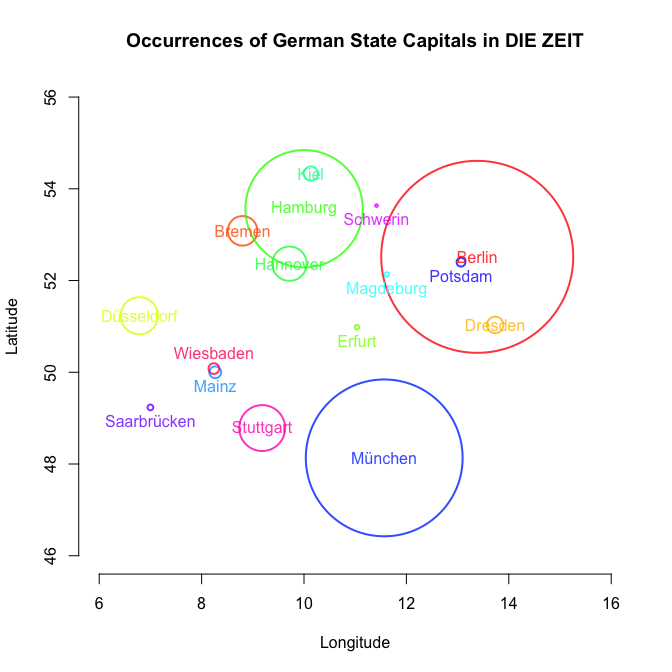